# AGEC 936 - Module 1

Synthetic Control Methods

Jisang Yu  
Kansas State University

# When do DinD research designs work

- Parallel trend assumption
  - This is the key!
  - Staggered DinD designs also need the parallel trend assumption.
- For statistical power and inference, we need enough obervations in each *group*.
- What if
  - we cannot assume the parallel trend?
  - we only have **one** observation for treated unit?

# Synthetic control methods

- Foundational piece: Abadie, Diamond, and Hainmueller (2010) (originally developed by Abadie and Gardeazabal (2003))
- When?: (Normally but not necessarily), **one** treated unit ($i=1$), **many** control units, and (somewhat) long time period.
- Back to **potential outcome representation**: we want
  $$\tau_{t}=y_{1t}(1)-y_{1t}(0)$$
- What do we observe?
  - $y_{1t}=y_{1t}(0)$ if $t<t^*$,
  - $y_{1t}=y_{1t}(1)$ if $t \geq t^*$,
  - $y_{it}=y_{it}(0)$ for $i\neq1$.
  - But, **we need $y_{1t}(0)$ for $t>t^*$!**
- The **key idea**: Let’s combine $y_{it}$ for $i\neq1$ to estimate $y_{1t}(0)$ for $t>t^*$.
- Underlying model for the potential outcome, $y_{it}(0)$, is (equation (1) of Abadie, Diamond, and Hainmueller (2010))
  $$y_{it}(0)=\delta_{t}+\theta_t Z_i + \lambda_t\mu_i+\varepsilon_{it}.$$
- Suppose if there are $w^*$ that satisfy
  $$\sum_{j=2} w^{*}_j y_{js}=y_{1s}\;\;\forall\;\;s<t^*,$$
  $$\sum_{j=2} w^{*}_j Z_{j}=Z_{1}\;\;\forall\;\;s<t^*.$$
- Under certain conditions, we have $\sum_{j=2} w^{*}_j y_{jt}$ approximately equal to $y_{1t}(0)$. Thus, we can use
  $$\hat{\tau}_t=y_{1t}-\sum_{j=2} w^{*}_j y_{jt}\;\;\forall\;\;t>t^*$$
- Estimation (see equation (7) of Abadie (2021)):
  $$Min_{w_j,j\neq1}\;\left(\sum_h v_h \left(X_{1h}-\sum_{j=2} w_j
  X_{jh}\right)^2\right)$$
  subject to
  $$w_j\geq 0\;\;\text{and}\;\;\sum_{j=2}w_j = 1$$
  and $X_h$ are “predictors”, which include $y_{js}$ for $j\neq 1$ and $s<t^*$, and $Z_j$ for $j\neq1$.
- How do we choose $v_h$?: Abadie, Diamond, and Hainmueller (2010) uses $v_h$ such that produce $w_j$ such that they minimize the out-of-sample mean squared prediction error for some set times in the pre-intervention period.
- Seems cool… any issues?

# A simple simulation

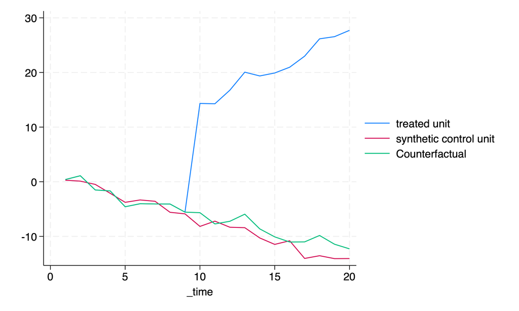

```stata
clear all
set obs 5
set seed 1234

*id
gen id=_n

*time invariant var
gen x=3*rnormal()

*expand
expand 20

*time var
bys id: gen t=_n

*error
gen e=rnormal()

*treatment to id=1 after t=10
gen d=0
replace d=1 if id==1 & t>=10

*outcome
gen y=2+0.5*x+0.5*t*x+2*t*d+e

*synth
xtset id t
*compare with actual counterfactual
tempfile temp
synth y y(1) y(2) y(3) y(4) y(5) x(1(1)5), trunit(1) trperiod(10) mspeperiod(5(1)8) keep(`temp')

use `temp', clear
gen real_counterfactual=_Y_treated
replace real_counterfactual=_Y_treated-2*_time if _time>=10
label var real_counterfactual "Counterfactual"

*plot
tw (line _Y_treated _time) (line _Y_synthetic _time) (line real_counterfactual _time), graphregion(color(white))
graph export "synth.png", replace
```

# An example (Abadie and Gardeazabal 2003)

```r
library(Synth)
data(basque)
#Data preparation
dataprep.out <- dataprep(
foo = basque,
predictors = c("school.illit", "school.prim", "school.med",
"school.high", "school.post.high", "invest"),
predictors.op = "mean",
time.predictors.prior = 1964:1969,
special.predictors = list(
list("gdpcap", 1960:1969 , "mean"),
list("sec.agriculture", seq(1961, 1969, 2), "mean"),
list("sec.energy", seq(1961, 1969, 2), "mean"),
list("sec.industry", seq(1961, 1969, 2), "mean"),
list("sec.construction", seq(1961, 1969, 2), "mean"),
list("sec.services.venta", seq(1961, 1969, 2), "mean"),
list("sec.services.nonventa", seq(1961, 1969, 2), "mean"),
list("popdens", 1969, "mean")),
dependent = "gdpcap",
unit.variable = "regionno",
unit.names.variable = "regionname",
time.variable = "year",
treatment.identifier = 17,
controls.identifier = c(2:16, 18),
time.optimize.ssr = 1960:1969,
time.plot = 1955:1997)
#Further variable consolidation and manipulation following Abadie et al 2011 (Journal of Statistical Software)
dataprep.out$X1["school.high",] <- dataprep.out$X1["school.high",] +
dataprep.out$X1["school.post.high",]
dataprep.out$X1 <- as.matrix(dataprep.out$X1[
-which(rownames(dataprep.out$X1) == "school.post.high"),])
dataprep.out$X0["school.high",] <- dataprep.out$X0["school.high",] +
dataprep.out$X0["school.post.high",]
dataprep.out$X0 <- dataprep.out$X0[
-which(rownames(dataprep.out$X0) == "school.post.high"),]
lowest <- which(rownames(dataprep.out$X0) == "school.illit")
highest <- which(rownames(dataprep.out$X0) == "school.high")
dataprep.out$X1[lowest:highest,] <-
(100 * dataprep.out$X1[lowest:highest,]) /
sum(dataprep.out$X1[lowest:highest,])
dataprep.out$X0[lowest:highest,] <-
100 * scale(dataprep.out$X0[lowest:highest,], center = FALSE,
scale = colSums(dataprep.out$X0[lowest:highest,]))
#Synth estimation
synth.out <- synth(data.prep.obj = dataprep.out, method = "BFGS")
synth.tables <- synth.tab(dataprep.res = dataprep.out,synth.res = synth.out)
hat.w.scm1<-synth.tables$tab.w[,1]
#Observed and Synthetic Basque
obs.Y.1t<-dataprep.out$Y1
hat.Y.1t.scm1<-(dataprep.out$Y0)%*%hat.w.scm1
```

```r
#Weights
synth.tables$tab.w
```

```
   w.weights                   unit.names unit.numbers
2      0.000                    Andalucia            2
3      0.000                       Aragon            3
4      0.000       Principado De Asturias            4
5      0.000             Baleares (Islas)            5
6      0.000                     Canarias            6
7      0.000                    Cantabria            7
8      0.000              Castilla Y Leon            8
9      0.000           Castilla-La Mancha            9
10     0.851                     Cataluna           10
11     0.000         Comunidad Valenciana           11
12     0.000                  Extremadura           12
13     0.000                      Galicia           13
14     0.149        Madrid (Comunidad De)           14
15     0.000           Murcia (Region de)           15
16     0.000 Navarra (Comunidad Foral De)           16
18     0.000                   Rioja (La)           18
```

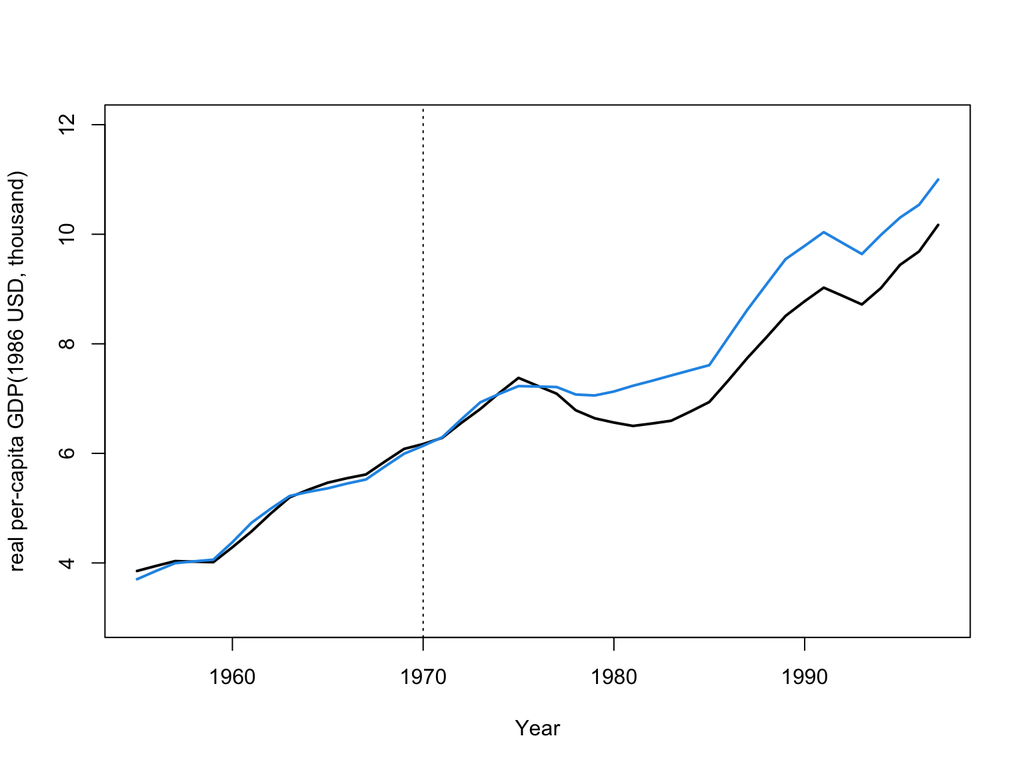

```r
#Plot
Year<-1955:1997
plot(Year,obs.Y.1t,ylim=c(3,12),ylab="real per-capita GDP(1986 USD, thousand)",type='l',lwd=2)
abline(v=1970,lty=3,col=1)
lines(Year,hat.Y.1t.scm1,col=4,lwd=2,lty=1)
```

# Different cross-validation splits

- What if we use 1955 - 1969 instead of 1960 - 1969?

```r
library(Synth)
data(basque)
#Data preparation
dataprep.out <- dataprep(
foo = basque,
predictors = c("school.illit", "school.prim", "school.med",
"school.high", "school.post.high", "invest"),
predictors.op = "mean",
time.predictors.prior = 1964:1969,
special.predictors = list(
list("gdpcap", 1960:1969 , "mean"),
list("sec.agriculture", seq(1961, 1969, 2), "mean"),
list("sec.energy", seq(1961, 1969, 2), "mean"),
list("sec.industry", seq(1961, 1969, 2), "mean"),
list("sec.construction", seq(1961, 1969, 2), "mean"),
list("sec.services.venta", seq(1961, 1969, 2), "mean"),
list("sec.services.nonventa", seq(1961, 1969, 2), "mean"),
list("popdens", 1969, "mean")),
dependent = "gdpcap",
unit.variable = "regionno",
unit.names.variable = "regionname",
time.variable = "year",
treatment.identifier = 17,
controls.identifier = c(2:16, 18),
time.optimize.ssr = 1955:1969,
time.plot = 1955:1997)
#Further variable consolidation and manipulation following Abadie et al 2011 (Journal of Statistical Software)
dataprep.out$X1["school.high",] <- dataprep.out$X1["school.high",] +
dataprep.out$X1["school.post.high",]
dataprep.out$X1 <- as.matrix(dataprep.out$X1[
-which(rownames(dataprep.out$X1) == "school.post.high"),])
dataprep.out$X0["school.high",] <- dataprep.out$X0["school.high",] +
dataprep.out$X0["school.post.high",]
dataprep.out$X0 <- dataprep.out$X0[
-which(rownames(dataprep.out$X0) == "school.post.high"),]
lowest <- which(rownames(dataprep.out$X0) == "school.illit")
highest <- which(rownames(dataprep.out$X0) == "school.high")
dataprep.out$X1[lowest:highest,] <-
(100 * dataprep.out$X1[lowest:highest,]) /
sum(dataprep.out$X1[lowest:highest,])
dataprep.out$X0[lowest:highest,] <-
100 * scale(dataprep.out$X0[lowest:highest,], center = FALSE,
scale = colSums(dataprep.out$X0[lowest:highest,]))
#Synth estimation
synth.out <- synth(data.prep.obj = dataprep.out, method = "BFGS")
synth.tables <- synth.tab(dataprep.res = dataprep.out,synth.res = synth.out)
hat.w.scm1<-synth.tables$tab.w[,1]
#Observed and Synthetic Basque
obs.Y.1t<-dataprep.out$Y1
hat.Y.1t.scm1<-(dataprep.out$Y0)%*%hat.w.scm1
```

```r
#Weights
synth.tables$tab.w
```

```
   w.weights                   unit.names unit.numbers
2      0.000                    Andalucia            2
3      0.000                       Aragon            3
4      0.000       Principado De Asturias            4
5      0.000             Baleares (Islas)            5
6      0.000                     Canarias            6
7      0.000                    Cantabria            7
8      0.000              Castilla Y Leon            8
9      0.000           Castilla-La Mancha            9
10     0.831                     Cataluna           10
11     0.000         Comunidad Valenciana           11
12     0.000                  Extremadura           12
13     0.000                      Galicia           13
14     0.169        Madrid (Comunidad De)           14
15     0.000           Murcia (Region de)           15
16     0.000 Navarra (Comunidad Foral De)           16
18     0.000                   Rioja (La)           18
```

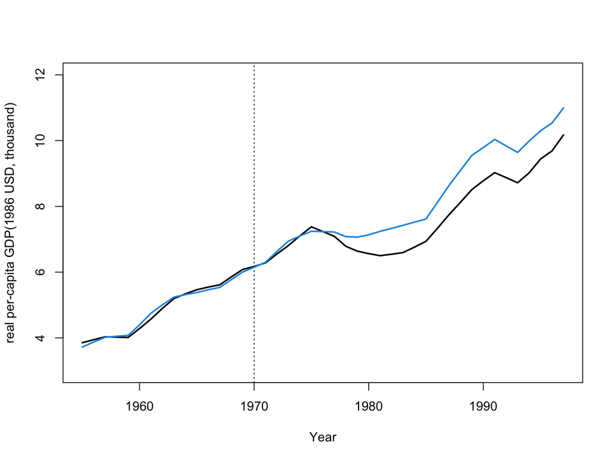

```r
#Plot
Year<-1955:1997
plot(Year,obs.Y.1t,ylim=c(3,12),ylab="real per-capita GDP(1986 USD, thousand)",type='l',lwd=2)
abline(v=1970,lty=3,col=1)
lines(Year,hat.Y.1t.scm1,col=4,lwd=2,lty=1)
```

# Placebo test

- Test with other region (Cataluna)

```r
dataprep.out <- dataprep(
foo = basque,
predictors = c("school.illit", "school.prim", "school.med",
"school.high", "school.post.high", "invest"),
predictors.op = "mean",
time.predictors.prior = 1964:1969,
special.predictors = list(
list("gdpcap", 1960:1969 , "mean"),
list("sec.agriculture", seq(1961, 1969, 2), "mean"),
list("sec.energy", seq(1961, 1969, 2), "mean"),
list("sec.industry", seq(1961, 1969, 2), "mean"),
list("sec.construction", seq(1961, 1969, 2), "mean"),
list("sec.services.venta", seq(1961, 1969, 2), "mean"),
list("sec.services.nonventa", seq(1961, 1969, 2), "mean"),
list("popdens", 1969, "mean")),
dependent = "gdpcap",
unit.variable = "regionno",
unit.names.variable = "regionname",
time.variable = "year",
treatment.identifier = 10,
controls.identifier = c(2:9, 11:16, 18),
time.optimize.ssr = 1960:1969,
time.plot = 1955:1997)
#Further variable consolidation and manipulation following Abadie et al 2011 (Journal of Statistical Software)
dataprep.out$X1["school.high",] <- dataprep.out$X1["school.high",] +
dataprep.out$X1["school.post.high",]
dataprep.out$X1 <- as.matrix(dataprep.out$X1[
-which(rownames(dataprep.out$X1) == "school.post.high"),])
dataprep.out$X0["school.high",] <- dataprep.out$X0["school.high",] +
dataprep.out$X0["school.post.high",]
dataprep.out$X0 <- dataprep.out$X0[
-which(rownames(dataprep.out$X0) == "school.post.high"),]
lowest <- which(rownames(dataprep.out$X0) == "school.illit")
highest <- which(rownames(dataprep.out$X0) == "school.high")
dataprep.out$X1[lowest:highest,] <-
(100 * dataprep.out$X1[lowest:highest,]) /
sum(dataprep.out$X1[lowest:highest,])
dataprep.out$X0[lowest:highest,] <-
100 * scale(dataprep.out$X0[lowest:highest,], center = FALSE,
scale = colSums(dataprep.out$X0[lowest:highest,]))
#Synth estimation
synth.out <- synth(data.prep.obj = dataprep.out, method = "BFGS")
synth.tables <- synth.tab(dataprep.res = dataprep.out,synth.res = synth.out)
hat.w.scm1<-synth.tables$tab.w[,1]
#Observed and Synthetic Cataluna
obs.Y.1t<-dataprep.out$Y1
hat.Y.1t.scm1<-(dataprep.out$Y0)%*%hat.w.scm1
```

```r
#Weights
synth.tables$tab.w
```

```
   w.weights                   unit.names unit.numbers
2      0.000                    Andalucia            2
3      0.000                       Aragon            3
4      0.036       Principado De Asturias            4
5      0.272             Baleares (Islas)            5
6      0.000                     Canarias            6
7      0.257                    Cantabria            7
8      0.000              Castilla Y Leon            8
9      0.000           Castilla-La Mancha            9
11     0.000         Comunidad Valenciana           11
12     0.000                  Extremadura           12
13     0.000                      Galicia           13
14     0.435        Madrid (Comunidad De)           14
15     0.000           Murcia (Region de)           15
16     0.000 Navarra (Comunidad Foral De)           16
18     0.000                   Rioja (La)           18
```

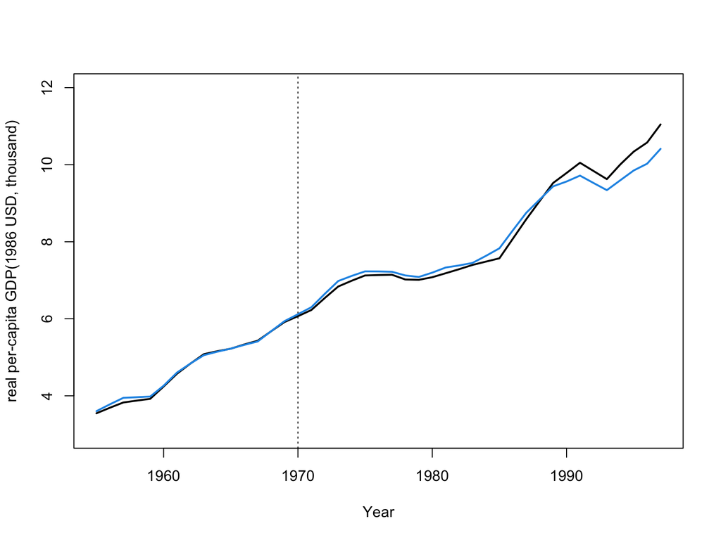

```r
#Plot
Year<-1955:1997
plot(Year,obs.Y.1t,ylim=c(3,12),ylab="real per-capita GDP(1986 USD, thousand)",type='l',lwd=2)
abline(v=1970,lty=3,col=1)
lines(Year,hat.Y.1t.scm1,col=4,lwd=2,lty=1)
```

# Some recent applications in agricultural/environmental/applied economics

- Immigration enforcement on agriculture (labor, crop production, and profitability): Luo and Kostandini (2021) (replication data/code available at [the AJAE article website](https://onlinelibrary.wiley.com/doi/full/10.1111/ajae.12271))
- Economic/health effects of the environmental or natural disaster: Guilfoos et al. (2018), Mohan (2017), and Coffman and Noy (2012)
- Impacts of trade or economic liberalization: Ijaz and Yu (forthcoming, JAAEA), Olper, Curzi, and Swinnen (2018), and Billmeier and Nannicini (2013)
- Impacts of carbon taxes on CO2 emissions: Andersson (2019)

# Things to consider (Abadie 2021)

- See the latest review of Abadie (2021)
- Highlighted features of Synthetic control method
  - No extrapolation: Why matter? See King and Zeng (2006).
  - Sparsity across “donors”: Interpretability
- Things to consider
  - Effect sizes and the volatility in the outcome of the treated unit.
  - Choosing “predictors” and $v_h$
  - Time dimension: the lengths of pre- and post- intervention periods
  - Donor pool
  - **Inference**

# Recent development

- Flexibility versus extrapolation risks
  - Possible negative weights: Doudchenko and Imbens (2016)
  - Non-negative but weights do not necessarily sum to one: Li (2020)
  - Non-negative, weights sum to one, but allow parallel shifts (a constant can be added or subtracted): Goh and Yu (2022)
- Predictors for the weights estimation: Kaul et al. (2021) and Botosaru and Ferman (2019)
- Imperfect pretreatment fit: Ben-Michael, Feller, and Rothstein (2021) and Ferman and Pinto (2021)
- Innovations in inference techniques
  - Frequentist approaches: e.g. Chernozhukov, Wüthrich, and Zhu (2021), Li (2020), and Firpo and Possebom (2018)
  - Bayesian approaches: e.g. Goh and Yu (2022) and Amjad, Shah, and Shen (2018)
- Extension to disaggregated data: Ben-Michael, Feller, and Rothstein (2022), Abadie and L’Hour (2021), and Arkhangelsky et al. (2021)

# Synthetic Difference-in-Differences (Arkhangelsky et al. (2021))

- Basic ideas
  - Obtain unit weights (denoted as $\omega$) by solving similar optimization problem as the synthetic control method.
  - Obtain time weights (denoted as $\lambda$) – similar to the unit weights but the goal is to create ``synthetic post”.
  - Estimate the weighted DID regression (weighted TWFE)
- Advantage: Arguably more robust compared to SC or DID
- Inference: Jackknife, Bootstrap, or Placebo
- Implementation: See [Github link](https://github.com/synth-inference/synthdid/)

# Some time-series considerations in Panel data setting

- Panel unit root test
  - Tests for stationarity of the panel time series
  - Each test has either different null or different asymptotics (see page 8 of xtunitroot Stata help file)
  - Some references: Levin, Lin, and Chu (2002), Im, Pesaran, and Shin (2003), or Stata’s xtunitroot help file.
- Panel Vector Autoregression: Be aware of Nickell bias (Dissappears with large T, for short T, see Arellano-Bond-type first-differenced GMM estimators)
  - Some references: Abrigo and Love (2016) and Holtz-Eakin, Newey, and Rosen (1988)

# Next week

[Panel IV/GMM and Shift-share deisgn](https://jisangyu-agecon.github.io/AGEC936/Lectures/AGEC936_Panel_IV_GMM.html)

# References

Abadie, Alberto. 2021. “Using Synthetic Controls: Feasibility, Data Requirements, and Methodological Aspects.” *Journal of Economic Literature* 59 (2): 391–425.

Abadie, Alberto, Alexis Diamond, and Jens Hainmueller. 2010. “Synthetic Control Methods for Comparative Case Studies: Estimating the Effect of California’s Tobacco Control Program.” *Journal of the American Statistical Association* 105 (490): 493–505.

Abadie, Alberto, and Javier Gardeazabal. 2003. “The Economic Costs of Conflict: A Case Study of the Basque Country.” *American Economic Review* 93 (1): 113–32.

Abadie, Alberto, and Jérémy L’Hour. 2021. “A Penalized Synthetic Control Estimator for Disaggregated Data.” *Journal of the American Statistical Association* 116 (536): 1817–34.

Abrigo, Michael RM, and Inessa Love. 2016. “Estimation of Panel Vector Autoregression in Stata.” *The Stata Journal* 16 (3): 778–804.

Amjad, Muhammad, Devavrat Shah, and Dennis Shen. 2018. “Robust Synthetic Control.” *The Journal of Machine Learning Research* 19 (1): 802–52.

Andersson, Julius J. 2019. “Carbon Taxes and CO 2 Emissions: Sweden as a Case Study.” *American Economic Journal: Economic Policy* 11 (4): 1–30.

Arkhangelsky, Dmitry, Susan Athey, David A. Hirshberg, Guido W. Imbens, and Stefan Wager. 2021. “Synthetic Difference-in-Differences.” *American Economic Review* 111 (12): 4088–118. https://doi.org/10.1257/aer.20190159.

Ben-Michael, Eli, Avi Feller, and Jesse Rothstein. 2021. “The Augmented Synthetic Control Method.” *Journal of the American Statistical Association* 116 (536): 1789–1803.

———. 2022. “Synthetic Controls with Staggered Adoption.” *Journal of the Royal Statistical Society: Series B (Statistical Methodology)*. https://doi.org/doi.org/10.1111/rssb.12448.

Billmeier, Andreas, and Tommaso Nannicini. 2013. “Assessing Economic Liberalization Episodes: A Synthetic Control Approach.” *Review of Economics and Statistics* 95 (3): 983–1001.

Botosaru, Irene, and Bruno Ferman. 2019. “On the Role of Covariates in the Synthetic Control Method.” *The Econometrics Journal* 22 (2): 117–30.

Chernozhukov, Victor, Kaspar Wüthrich, and Yinchu Zhu. 2021. “An Exact and Robust Conformal Inference Method for Counterfactual and Synthetic Controls.” *Journal of the American Statistical Association* 116 (536): 1849–64.

Coffman, Makena, and Ilan Noy. 2012. “Hurricane Iniki: Measuring the Long-Term Economic Impact of a Natural Disaster Using Synthetic Control.” *Environment and Development Economics* 17 (2): 187–205.

Doudchenko, Nikolay, and Guido W Imbens. 2016. “Balancing, Regression, Difference-in-Differences and Synthetic Control Methods: A Synthesis.” National Bureau of Economic Research.

Ferman, Bruno, and Cristine Pinto. 2021. “Synthetic Controls with Imperfect Pretreatment Fit.” *Quantitative Economics* 12 (4): 1197–1221.

Firpo, Sergio, and Vitor Possebom. 2018. “Synthetic Control Method: Inference, Sensitivity Analysis and Confidence Sets.” *Journal of Causal Inference* 6 (2).

Goh, Gyuhyeong, and Jisang Yu. 2022. “Synthetic Control Method with Convex Hull Restrictions: A Bayesian Maximum a Posteriori Approach.” *The Econometrics Journal* 25 (1): 215–32.

Guilfoos, Todd, Dalton Kell, Andrew Boslett, and Elaine L Hill. 2018. “The Economic and Health Effects of the 2014 Chemical Spill in the Elk River, West Virginia.” *American Journal of Agricultural Economics* 100 (2): 609–24.

Holtz-Eakin, Douglas, Whitney Newey, and Harvey S Rosen. 1988. “Estimating Vector Autoregressions with Panel Data.” *Econometrica: Journal of the Econometric Society*, 1371–95.

Im, Kyung So, M Hashem Pesaran, and Yongcheol Shin. 2003. “Testing for Unit Roots in Heterogeneous Panels.” *Journal of Econometrics* 115 (1): 53–74.

Kaul, Ashok, Stefan Klößner, Gregor Pfeifer, and Manuel Schieler. 2021. “Standard Synthetic Control Methods: The Case of Using All Preintervention Outcomes Together with Covariates.” *Journal of Business & Economic Statistics*, 1–15.

King, Gary, and Langche Zeng. 2006. “The Dangers of Extreme Counterfactuals.” *Political Analysis* 14 (2): 131–59.

Levin, Andrew, Chien-Fu Lin, and Chia-Shang James Chu. 2002. “Unit Root Tests in Panel Data: Asymptotic and Finite-Sample Properties.” *Journal of Econometrics* 108 (1): 1–24.

Li, Kathleen T. 2020. “Statistical Inference for Average Treatment Effects Estimated by Synthetic Control Methods.” *Journal of the American Statistical Association* 115 (532): 2068–83.

Luo, Tianyuan, and Genti Kostandini. 2021. “Stringent Immigration Enforcement and Responses of the Immigrant-Intensive Sector: Evidence from e-Verify Adoption in Arizona.” *American Journal of Agricultural Economics*.

Mohan, Preeya. 2017. “The Economic Impact of Hurricanes on Bananas: A Case Study of Dominica Using Synthetic Control Methods.” *Food Policy* 68: 21–30.

Olper, Alessandro, Daniele Curzi, and Johan Swinnen. 2018. “Trade Liberalization and Child Mortality: A Synthetic Control Method.” *World Development* 110: 394–410.